# Kompetensförsörjning i Dalarna

Skapad av: Samhällsanalys, Region Dalarna  
Senast uppdaterad: 2023-12-12

# 1 Introduktion

I ljuset av en ständigt föränderlig arbetsmarknad och det accelererande tempot inom teknologisk utveckling står Dalarna inför utmaningar och möjligheter när det gäller att säkerställa en robust och hållbar kompetensförsörjning. I Dalarna finns en stor variation av industrier som behöver kompetensförsörjas, allt ifrån en högteknologisk industri till en turism industri baserad på dalarnas kulturella kontext och hållbarhet. Denna rapport är avsedd att belysa de viktigaste aspekterna av regionens nuvarande och framtida kompetenslandskap, identifiera trender och behov, samt föreslå strategier för att möta dessa utmaningar på ett proaktivt sätt. Rapporten kommer även att utforska de centrala sektorerna och branscherna som driver regionens ekonomi. Vidare kommer den att analysera befintliga kompetensresurser, identifiera eventuella luckor och framhäva möjligheter för kompetensutveckling och nytänkande samarbete mellan näringsliv, utbildningsinstitutioner och offentliga sektorn. Denna rapport är avsedd att fungera som en grund för informerade beslut och samverkan, med målet att säkra regionens framtid genom en stark och anpassningsbar kompetensförsörjning.

I Dalarna har de unga (0-19 år) samt de arbetsföra (20-64) minskat sedan 1968, medan de äldre (65-79 år och 80+ år) har ökat under samma tidsperiod, en utveckling som dessutom prognostiseras fortsätta i framtiden. Det gör att regionen kan komma att stå inför ett flertal utmaningar i framtiden, däribland:

- Arbetskraftsbrist: Minskningen av unga och arbetsföra personer kan resultera i en brist på arbetskraft. Detta kan vara särskilt påtagligt inom vissa sektorer och yrken, vilket kan hämma ekonomisk tillväxt och innovation.
- Ökad börda på sociala trygghetssystem: Med en ökande andel äldre människor ökar behovet av hälso- och sjukvård samt pensioner. Detta kan öka belastningen på sociala trygghetssystem och offentliga finanser om det inte finns tillräckliga ekonomiska resurser för att stödja den åldrande befolkningen.
- Strukturella förändringar på arbetsmarknaden: Arbetsmarknaden kan genomgå strukturella förändringar för att anpassa sig till den förändrade demografiska profilen. Det kan innebära ökad efterfrågan på teknologiska lösningar, automation och andra effektiviseringsåtgärder för att kompensera för bristen på arbetskraft.
- Ökad efterfrågan på vårdtjänster: En ökande äldre befolkning kan leda till en ökad efterfrågan på hälso- och sjukvårdstjänster och äldreomsorg. Detta kan kräva investeringar och anpassningar inom hälso- och sjukvårdssystemet för att möta behoven hos den äldre befolkningen.

[figure not shown]

Figur 1

Den största näringen i Dalarna, där flest arbetar, var under 2021 hälso- och sjukvården, som dessutom har ökat något under 2010-talet. Även inom handel, transport, magasinering och kommunikation samt utvinning av mineral och tillverkningsindustri arbetade många i Dalarna 2021. I den sistnämnda branschen har dock antalet förvärvsarbetande minskat stadigt sedan 1990-talet. Bland övriga branscher har antalet förvärvsarbetande ökat inom bland annat kreditinstitut, fastighetsförvaltning och företagstjänster samt forskning, utveckling och utbildning.

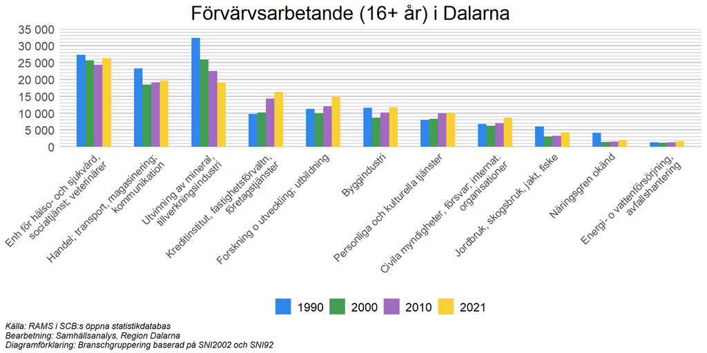

Figur 2

I Dalarnas största kommun, Falun, jobbar majoriteten inom vård och omsorg, följt av utbildning, företagstjänster, offentlig förvaltning, handel, tillverkning, bygg, kultur, fritid och nöje. I Dalarnas näst största kommun, Borlänge, så jobbar majoriteten av befolkningen inom handel, följt av vård och omsorg, offentlig förvaltning, utbildning, tillverkning, företagstjänster, bygg och transport. I Ludvika så är det vanligast att jobba inom tillverkningsindustrin, följt av vård och omsorg, utbildning, handel, företagstjänster samt bygg. I Avesta så är det även där vanligast att jobba inom tillverkning, följt av vård och omsorg, handel, utbildning, bygg, företagstjänster samt transport. I Mora så jobbar de flesta inom vård och omsorg, följt av tillverkning, handel, utbildning, bygg och företagstjänster. I Leksand arbetar de flesta inom handel, följt av vård och omsorg, utbildning, tillverkning, bygg och företagstjänster, hotell och restaurang samt jord- och skogsbruk. I Hedemora arbetar de flesta inom vård och omsorg, följt av tillverkning, utbildning, handel och bygg. I Säter så är den största branschen vård och omsorg, sen i fallande ordning kommer följande branscher: utbildning, bygg, tillverkning, jord- och skogsbruk, kultur, fritid och nöje, samt handel. I Rättvik arbetar de flesta inom vård och omsorg, följt av utbildning, bygg, tillverkning, handel, jord- och skogsbruk, företagstjänster samt hotell och restaurang. I Smedjebacken arbetar de flesta inom tillverkningsindustrin, följt av vård och omsorg, utbildning, bygg, handel samt företagstjänster.  
I Gagnef är den största branschen där flest arbetar inom är vård och omsorg, följt av tillverkningsekonomi, utbildning, bygg, offentlig förvaltning, samt handel. I Malung-Sälen arbetar flest inom vård och omsorg, följt av bygg, kultur, fritid och nöje, utbildning, handel, tillverkning och företagstjänster.  
I Älvdalen så jobbar flertalet inom vård och omsorg, bygg, tillverkning, handel, utbildning och I Orsa så jobbar de flesta inom vård och omsorg, följt av bygg, transport, utbildning, kultur och fritid, samt jord- och skogsbruk. I Dalarnas minsta kommun sett till befolkning, Vansbro, jobbar de flesta inom tillverkningsindustrin, följt av handel, vård och omsorg, utbildning, och bygg. Det finns fler branscher i varje kommun, vilket kan ses i figur 3.

[figure not shown]

Figur 3

I den vänstra cirkeln finns branscher efter antal anställda bland kvinnor, i den högra finns antal branscher efter anställda män. Kvinnor arbetar framförallt inom vård och omsorg och utbildning. Även handel, offentlig förvaltning, företagstjänster, tillverkning, kultur, samt fritid och nöje i fallande ordning. I den högra cirkeln så visas det att män framförallt jobbar inom tillverkningsindustrin, bygg, handel, företagstjänster, vård och omsorg, transport, utbildning, offentlig förvaltning samt jord- och skogsbruk.

[figure not shown]

Figur 3

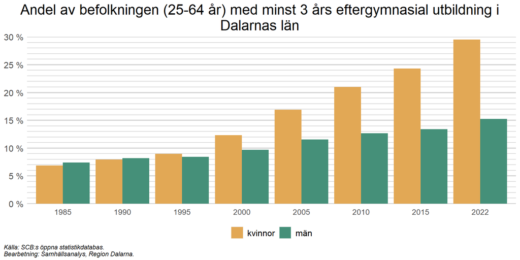

Figur 6

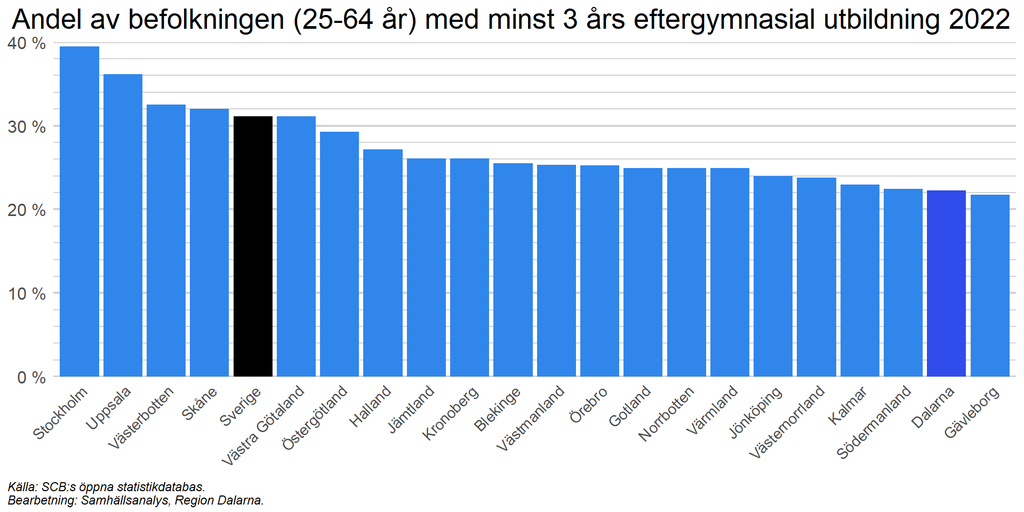

Figur 7

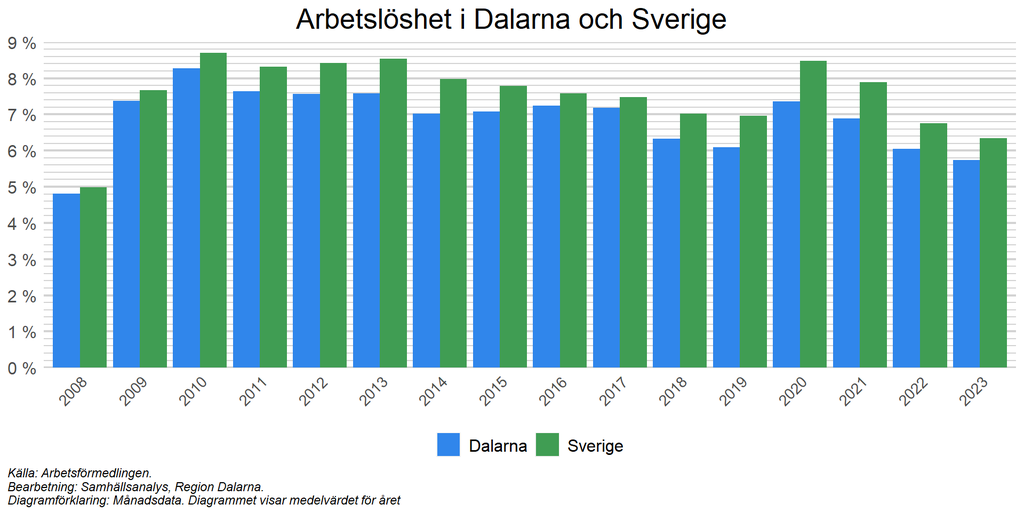

Figur 7

# 2 Efterfrågan, nu och framledes

Efterfrågan på arbetskraft är i grunden ett teoretiskt begrepp som inte är helt rättfram att mäta. Historisk data över exempelvis antal förvärvsarbetande i olika branscher visar när efterfrågan möter utbud, dvs. när en person blir anställd. Efterfrågan kan dock överstiga utbudet, det blir exempelvis allt vanligare att företag har svårt att hitta arbetskraft, något som inte återspeglas i figurerna nedan. I detta avsnitt diskuteras vad de som förvärvsarbetar i Dalarna arbetar med, men också hur kvalificerade deras yrken är och åldersstrukturen på arbetsmarknaden.

## 2.1 Förvärvsarbetande

**Mer information om statistiken**

Förvärvsarbetande omfattar både anställda och företagare. Har personen fått en lön i november som överstiger 99 kronor klassificeras personen som förvärvsarbetande. För egenföretagare gäller, liksom tidigare, att de personer som under referensåret har deklarerat för aktiv näringsverksamhet klassificeras som förvärvsarbetande.

I Dalarna var den klart största branschen 2021 , sett till antalet förvärvsarbetande, vård och omsorg med ungefär 26 300 anställda. Detta kan delvis förklaras med att befolkningen i Dalarna, precis som många andra glesbefolkade län, har en relativt hög medelålder, något som medför att mer vård och omsorg efterfrågas. Andra branscher med många anställda i Dalarna är tillverkning och utvinning samt utbildning, med ca 19 100 respektive ungefär 14 800 anställda. Störst andel kvinnor återfinns inom vård och omsorg där ca 79 procent av de förvärvsarbetande är kvinnor, medan störst andel män återfinns inom bygg där ca 92 procent av de förvärvsarbetande är män.

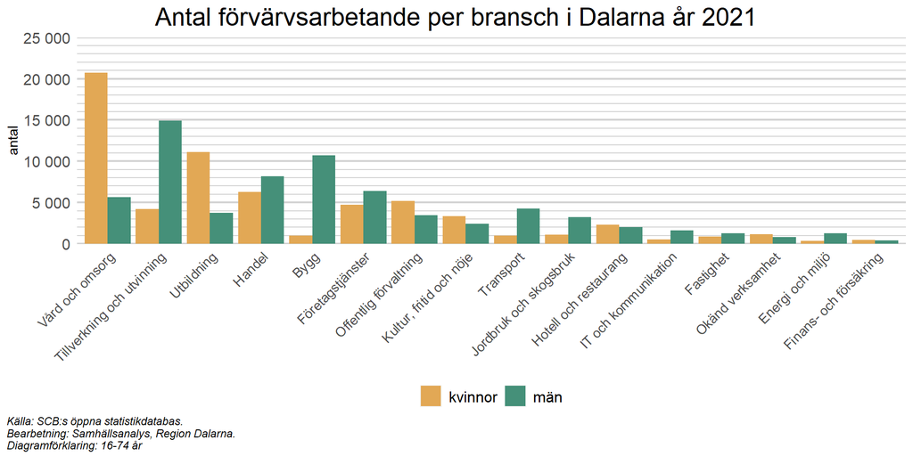

Figur 7

Hur många som jobbar inom olika branscher i Dalarna har förändrats genom åren. En tydlig utveckling, mellan 1990 och 2021 är att många fler arbetar i företag som sysslar med företagstjänster, finans mm, en ökning på ungefär 6 500 förvärvsarbetande. Detta beror sannolikt på att många företag idag lejer bort vissa tjänster,såsom lokalvård. Om exempelvis ett tillverkande företag som SSAB tidigare anställde lokalvårdare själva, så återfanns dessa inom branschen tillverkning och utvinning, men om företaget istället lejer ut sådan verksamhet till andra företag specialiserade inom området, räknas lokalvårdarna istället som förvärvsarbetande inom företagstjänster, finans mm.

Den bransch i Dalarna där antalet förvärvsarbetande har minskat mest är tillverkning och utvinning, med ca 13 300 färre förvärvsarbetande 2021 jämfört med 1990. Detta beror delvis på det som diskuterades i föregående stycke, men en viktigare förklaring är sannolikt att företag inom tillverkning och utvinning idag har en mer automatiserad produktion än de hade för 30 år sedan, något som medför att det behövs färre antal anställda i produktionen.

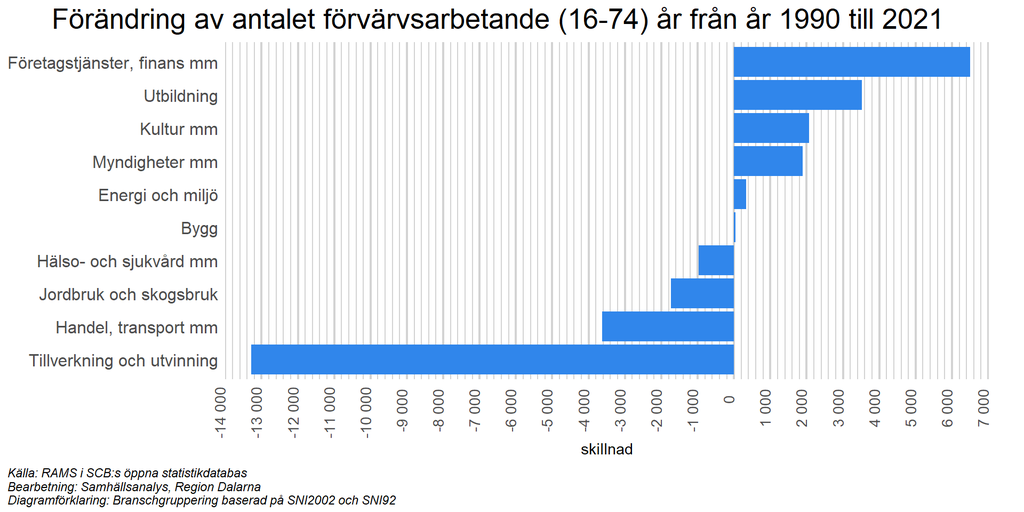

Figur 7

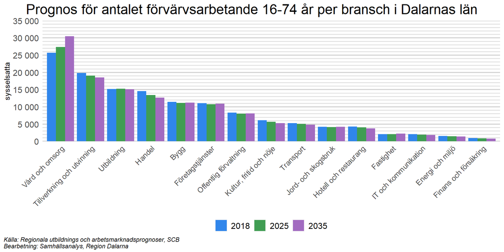

Figur 7

## 2.2 Kompetenskrav

**Mer information om statistiken**

För att beskriva kompetens och kvalifikationskrav har vi i denna rapport utgått ifrån yrkesregistret i SCB:s öppna statistikdatabas. I detta register delas yrken in i nio olika grupper. Utifrån dessa grupper har vi klassificerat de kategorier som syns i diagrammen nedan. Chefsyrken och yrken som kräver olika typer av högskolekompetens har samma benämning i vår klassificering som i SCB:s kategorisering. Yrken med krav på kortare utbildning eller indtroduktion har vi klassificerat som enklare yrken. Övriga yrken klassificeras som motsvarande gymnasial kompetens. Läs mer på SCB:s hemsida[^1]

Hur stor andel som jobbar inom yrken med olika former av kvalifikationskrav varierar relativt mycket mellan Sveriges län. Gotlands län har störst andel som arbetar inom enklare yrken, med ungefär 7 procent av de förvärvsarbetande i länet. Dock jobbar generellt relativt få inom dessa yrken, oavsett region. Om vi istället fokuserar på yrken med kvalifikationskrav som motsvarar gymnasial kompetens är skillnaderna större mellan Sveriges län. Minst andel återfinns i Stockholms län där ungefär 35 procent av de förvärvsarbetande har den typen av yrken, medan störst andel återfinns i Kalmar län med ungefär 55 procent av de förvärvsarbetande. För yrken med högre kvalifikationskrav, exempelvis “motsvarande fördjupad högskolekompetens”, är situationen mer eller mindre det omvända. Största andel har Stockholms län med ungefär 30 procent av de förvärvsarbetande, medan Kalmar län med ungefär 19 procent har lägst andel. Kvalifikationskraven i Dalarna påminner om de i Kalmar, med relativt stor andel av de förvärvsarbetande inom yrken med motsvarande gymnasial kompetens och färre inom yrken som kräver olika former av högskolekompetens.

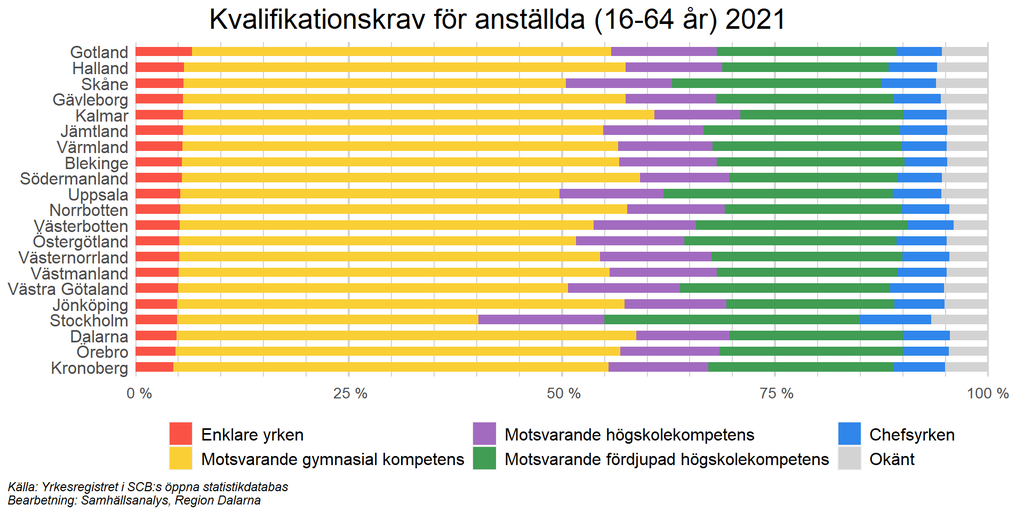

Figur 7

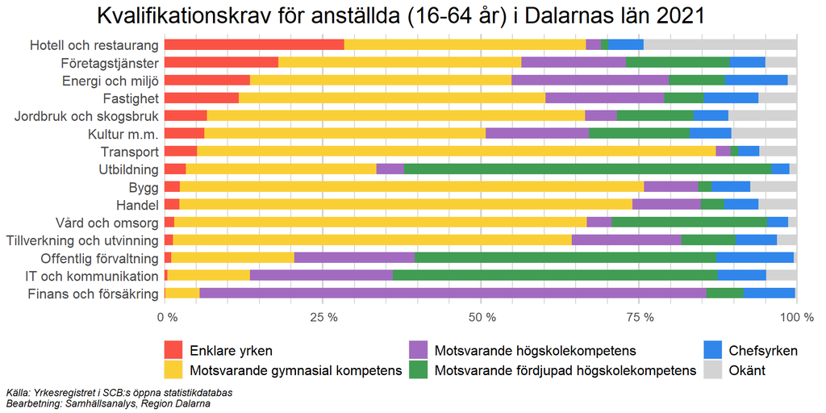

Figur 7

## 2.3 Åldersstruktur

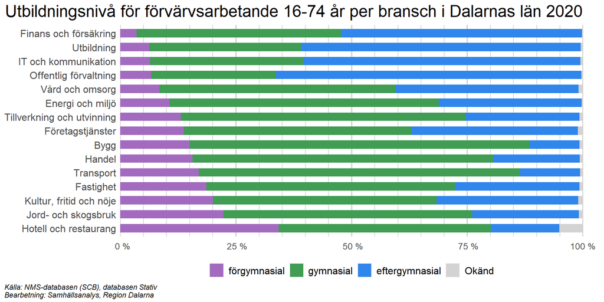

Figur 14

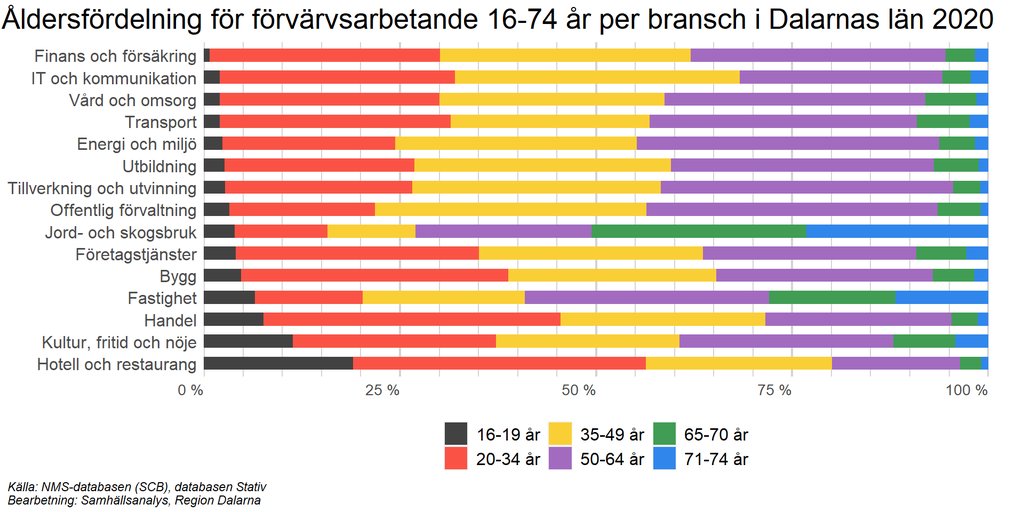

Figur 15

Störst antal personer över 50 år arbetar i Dalarna inom vård och omsorg. Ungefär 12 000 förvärvsarbetande inom branschen är minst 50 år och kommer således att gå i pension inom 15-20 år. Detta, i kombination med en befolkning som blir allt äldre och därför efterfrågar mer vård, leder till ett stort rekryteringsbehov inom vård och omsorg idag och i framtiden. Även inom tillverkning och utvinning är relativt många över 50 år, ca 8 500 förvärvsarbetande.

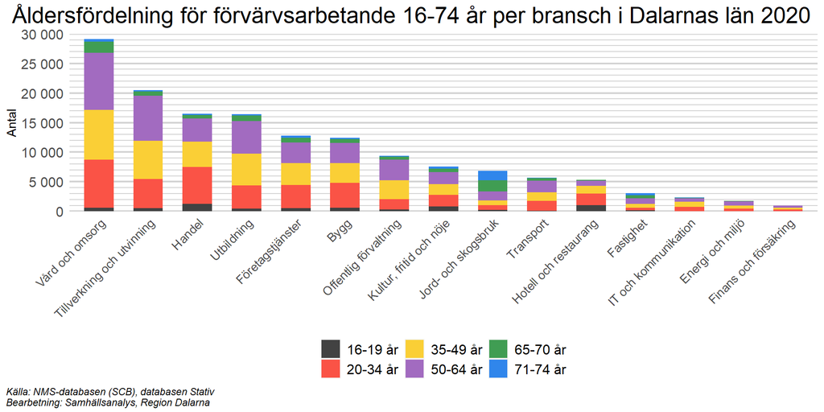

Figur 16

# 3 Utbud i Dalarnas län

## 3.1 Befolkning i arbetsför ålder

**Mer information om statistiken**

Inrikes flyttnetto är antalet som flyttar till en region från andra regioner i Sverige minus antalet som flyttar från en region till andra regioner i Sverige. Utrikes flyttnetto är invandring till en region minus utvandring/emigrering från en region. Demografisk förändring är den del av befolkningsförändringen som inte kan förklaras av inrikes och utrikes flyttnetto.

Bland Sveriges regioner är de befolkningsmässigt största även de vars befolkning i arbetsför ålder (20 - 64 år) har ökat mest det senaste dryga decenniet. Typiskt för dessa regioner är att de har ett positiv inrikes flyttnetto, dvs. människor i arbetsför ålder flyttar från andra delar av Sverige till exempelvis Stockholm eller Uppsala i större utsträckning än de flyttar därifrån. För många mindre regioner, såsom Dalarna, gäller det omvända. Härifrån flyttar många till andra regioner i Sverige, såväl utrikes födda som exempelvis har hamnat i Dalarna när de invandrat till Sverige, som inrikes födda.

I Sverige har invandringen (utrikes flyttnetto) överlag haft en positiv inverkan på den arbetsföra delen av befolkningens storlek det senaste dryga decenniet (de lila staplarna nedan). I vissa regioner, däribland Dalarna, motverkas denna ökning dock av ett negativt inrikes flyttnetto (gröna staplar) och en negativ demografisk förändring (blåa staplar), vilket sammantaget ger en minskande befolkning.

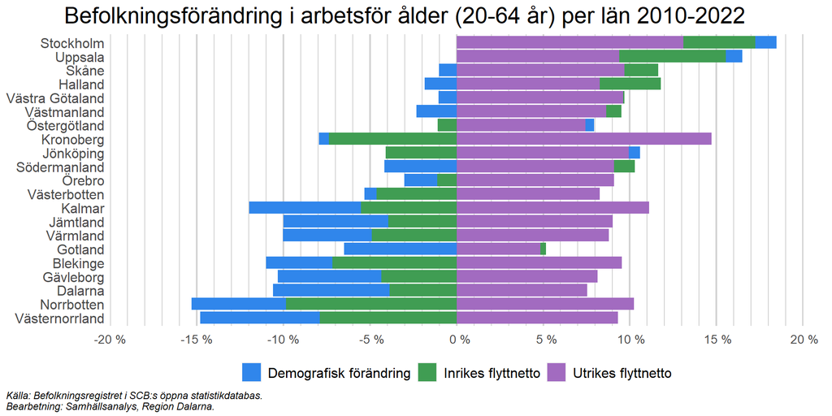

Figur 7

Om Dalarnas arbetsföra befolkning delas upp i inrikes och utrikes födda, framträder en mer nyanserad bild än den i föregående diagram. Tydligt är att Dalarnas arbetsföra befolkning minskat i antal de senaste decennierna och att detta drivs av att den inrikes födda delen av befolkningen minskar. I Dalarna minskade inrikes födda invånare i arbetsför ålder (20-64 år) från ungefär 145 000 personer år 2002 till ca 125 000 år 2022. Samtidigt har en relativt stor invandring medfört att utrikes födda invånare i arbetsför ålder har ökat från ungefär 12 000 personer år 2002 till ca 26 000 år 2022.

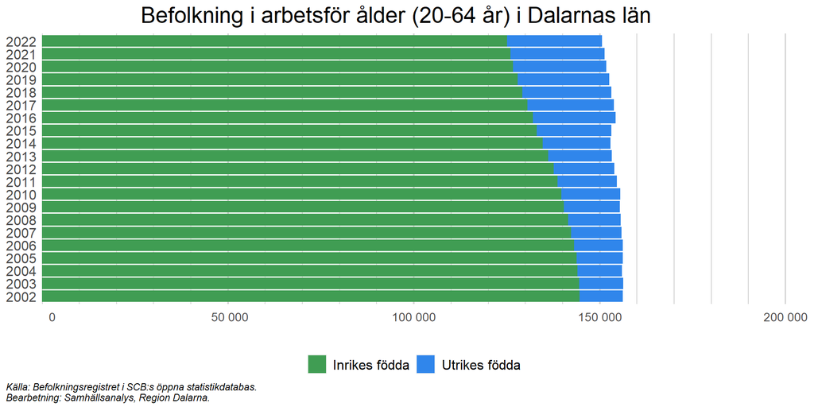

Figur 18

## 3.2 Hur många pendlar?

**Mer information om statistiken**

Andel inpendlare beräknas genom att dela antal inpendlare (personer som förvärvsarbetar i kommunen/regionen och bor i en annan kommun/region) med antal förvärvsarbetande som arbetar i kommunen/regionen (dagbefolkning). Andel utpendlare beräknas genom att dela antal utpendlare (personer som bor i kommunen/regionen och förvärvsarbetar i en annan kommun/region) med antal förvärvsarbetande som bor i kommunen/regionen (nattbefolkning).

För att fördjupa förståelsen för utbudet av arbetskraft bör lokala arbetsmarknadsregioner inkluderas i analysen, utöver kommuner eller län som analysenhet. Lokala arbetsmarknadsregioner skapas utifrån pendlingsrelationer mellan kommuner. Om jobbskapandet i den egna kommunen är svagt, kan närhet till andra kommuners arbetsmarknader möjliggöra pendling och medföra en totalt sett starkare arbetsmarknad.

Det som i första hand påverkar pendlingsmönster är närheten till större städer. Högst andel utpendlare i Sverige har Uppsala län, där närmare var fjärde boende som förvärvsarbetar gör det i ett annat län, Stockholm i stor utsträckning. Även Södermanland och Västmanland, som båda ligger relativt nära Stockholm, har stor utpendling. Störst andel inpendlare har Kronobergs län. I Dalarna är andelen förvärvsarbetande som pendlar över länsgräns relativt liten.

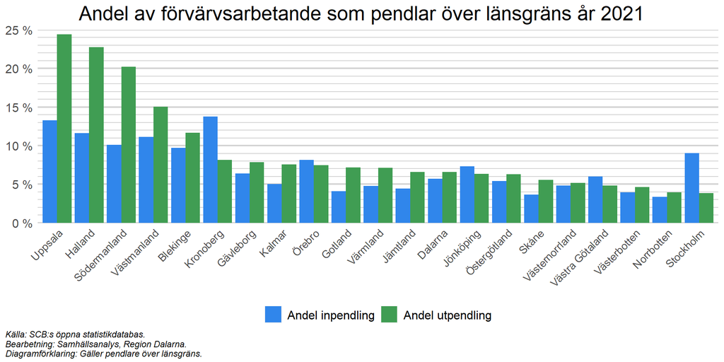

Figur 19

Att flera av kommunerna i Dalarna tillhör större arbetsmarknadsregioner blir tydligt i diagrammet nedan. Störst andel utpendling har Säter där ungefär 56 procent av de boende som förvärvsarbetar gör det i en annan kommun, i stor utsträckning Borlänge. Även Gagnef (pendling till Borlänge) och Smedjebacken (pendling till Ludvika) är kommuner där många pendlar till sitt arbete. Störst inpendling har Borlänge, där ungefär 38 procent av de förvärvsarbetande bor i en annan kommun. I norra Dalarna, med flera kommuner som till ytan är stora, exempelvis Malung-Sälen och Älvdalen, är situationen det omvända. Här bor och arbetar de allra flesta i samma kommun.

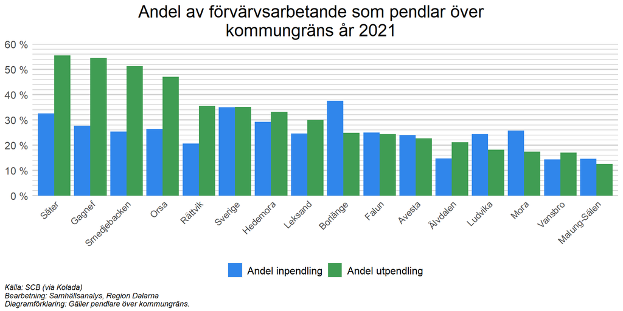

Figur 20

## 3.3 Utbildningsnivå

Utbildningsnivån bland Dalarnas invånare varierar såväl mellan kvinnor och män, som mellan inrikes och utrikes födda. Kvinnor har generellt en högre utbildningsnivå än män, ungefär var fjärde kvinna (inrikes och utrikes födda) har en eftergymnasial utbildning på minst 3 år, vilket motsvarar minst kandidatexamen. För män är motsvarande siffra ungefär 12 procent för inrikes födda och ca 18 procent för utrikes födda. Således är en större andel av de utrikes födda högutbildade. Annars återfinns den största skillnaden mellan grupperna bland de med lägst utbildningsnivå. I gruppen inrikes födda har i praktiken alla mellan 20 och 64 år åtminstone en högstadieutbildning. För utrikes födda är bilden helt annorlunda. Drygt 18 procent av de utrikes födda kvinnorna och ungefär 16 procent av de utrikes födda männen har en högsta utbildning som understiger högstadiet. Detta är sannolikt en av förklaringarna till att utrikes födda har en klart lägre sysselsättningsgrad än inrikes födda; personer med lägre utbildningsnivå har svårare att hitta jobb och står därför längre ifrån arbetsmarknaden.

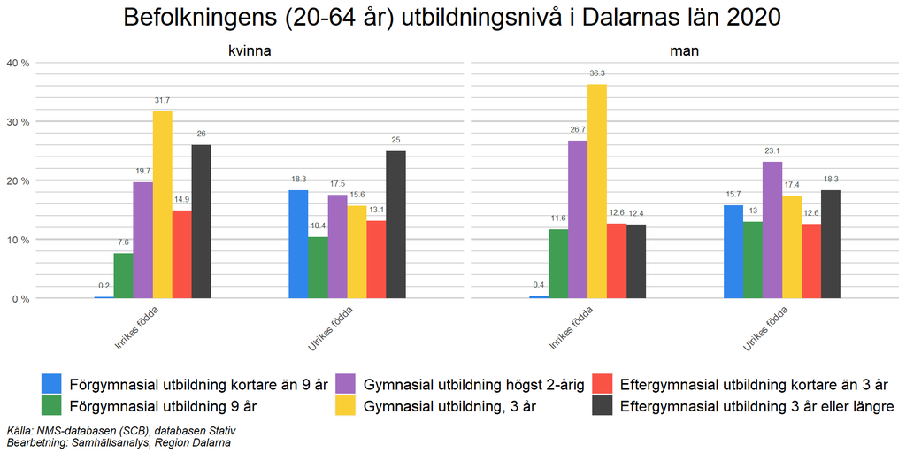

Figur 21

Det är även stora skillnader i utbildningsnivå mellan åldersgrupper. Om vi enbart fokuserar på de med en lägst utbildning, är det tydligt att äldre är överrepresenterade i Dalarna. Detta beror sannolikt på att utbildningsnivån i samhället har ökat över tid. Längre tillbaka vara det möjligt att gå ut högstadiet och sedan få ett jobb, vilket är avsevärt mycket svårare idag. Kraven på arbetsmarknaden har helt enkelt ökat. Antalet med låg utbildning minskar därefter med åldern ner till åldersgruppen runt 40 år, innan mönstret bryts. Att yngre åldersgrupper, framförallt de mellan 20 och 35 år, har relativt många med låg utbildning, beror troligtvis på att personer födda utrikes är överrepresenterade i dessa åldersgrupper. Som vi diskuterade i föregående avsnitt är det klart vanligare att utrikes födda har en förgymnasial utbildning som högsta utbildning.

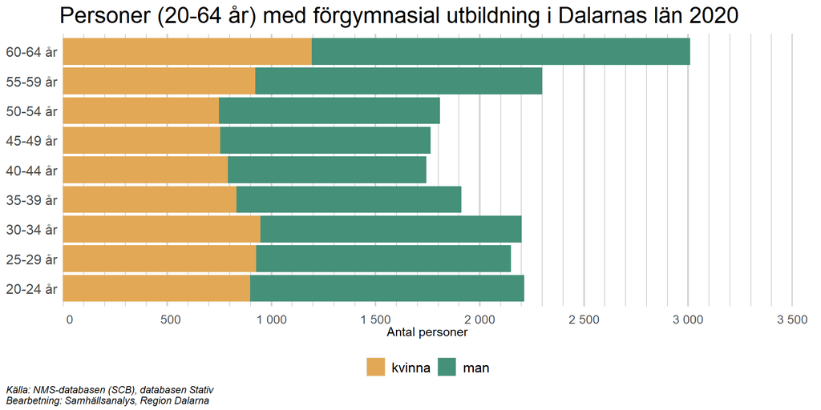

Figur 22

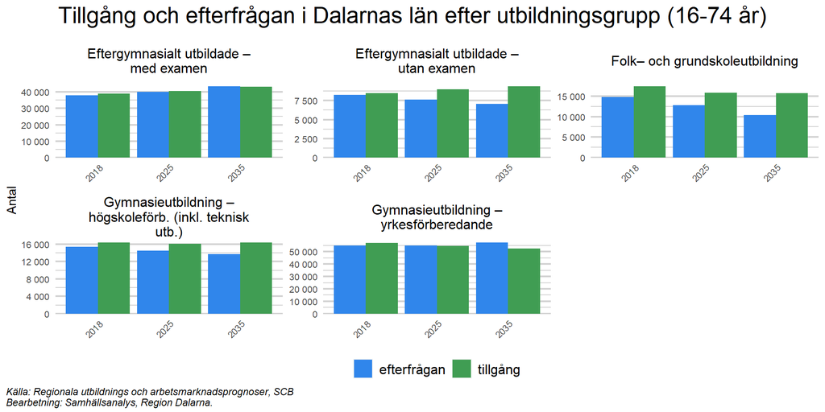

Figur 24

**Mer information om statistiken**

SCB har på uppdrag av Sveriges 21 regioner tagit fram regionala utbildnings- och arbetsmarknadsprognoser. I de regionala utbildnings- och arbetsmarknadsprognoserna presenteras framskrivningar över tillgång och efterfrågan på utbildade samt bedömningar av arbetsmarknadsläget år 2035 per län. Länsvisa prognoser och bedömningar görs för 22–55 utbildningsgrupper.

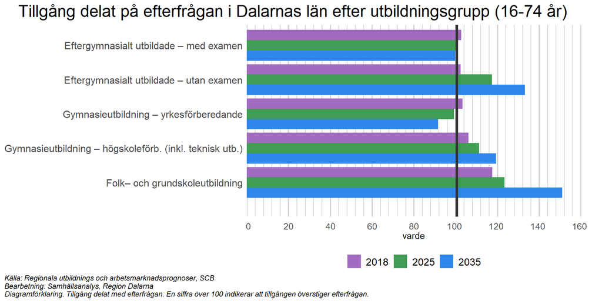

Figur 24

# 4 Gymnasiet, högskolan och YH

## 4.1 Gymnasiet

Vid antagningen hösten 2023 antogs flest unga i Dalarna till introduktionsprogrammet, ett program dit enbart personer som inte är behöriga till andra program antas. Bland de nationella programmen antogs flest till ekonomiprogrammet, samhällsvetenskapsprogrammet och teknikprogrammet. Högskoleförberedande program är således mest populära bland länets ungdomar. Bland yrkesförberedande program antogs flest till bygg- och anläggningsprogrammet respektive fordons- och transportprogrammet.

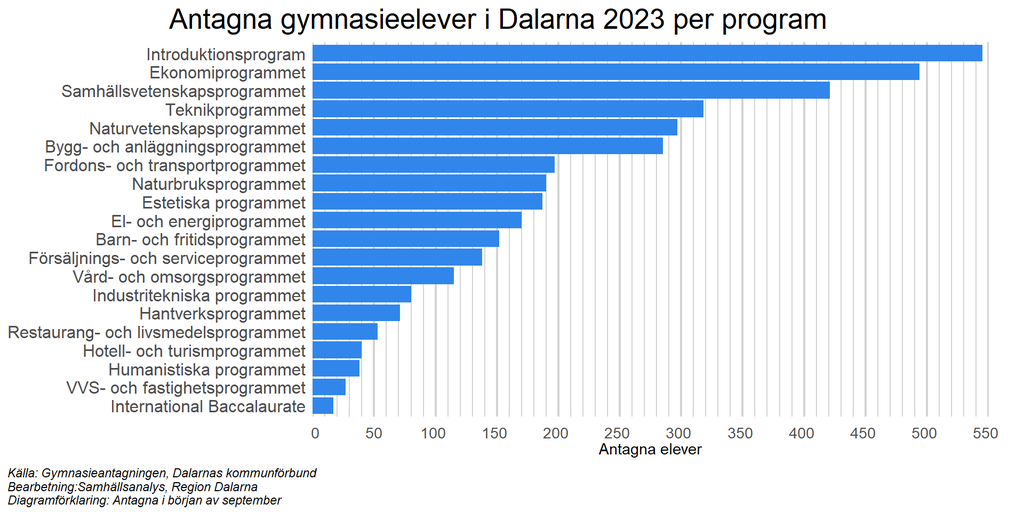

Figur 25

Det råder stora könsmässiga skillnader mellan antagna till olika program. För högskoleförberedande program är obalansen störst på samhällsvetenskapsprogrammet, dit klart flest tjejer antas och teknikprogrammet, dit klart flest pojkar antas. Bland yrkesförberedande program är det en överväldigande majoritet tjejer som antas till Vård- och omsorgsprogrammet medan en överväldigande majoritet killar antas till bygg- och anläggningsprogrammet och el- och energiprogrammet. Dessa obalanser återspeglas även senare i arbetslivet. Kvinnor är överrepresenterade inom vård och omsorg och utbildning, medan män är i klar majoritet inom byggsektorn. Om målsättningen är att skapa en mer jämställd fördelning mellan olika branscher i arbetslivet, är det således viktigt att börja arbetet redan i skolan. Det finns uppenbarligen stora skillnader mellan vilka val killar och tjejer gör redan då.

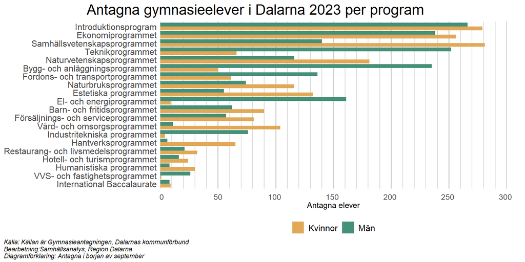

Figur 26

Det program som ökat klart mest i antalet antagna är introduktionsprogrammet. År 2011 antogs runt 91 personer till programmet, en siffra som ökade till 545 år 2023. Bland studieförberedande program är ökningen störst på ekonomiprogrammet, dit mer än dubbel så många antas idag som 2011. Bland program som i första hand kan ses som yrkesförberedande har antalet antagna till naturbruksprogrammet ökat avsevärt sedan 2011, medan antalet antagna till restaurang- och livsmedelsprogrammet och hotell och turismprogrammet har minskat tydligt.

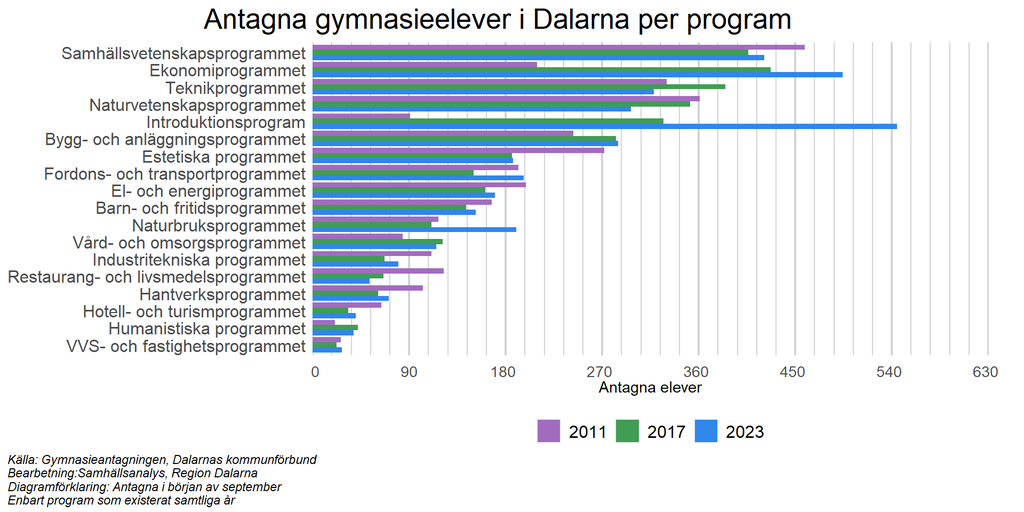

Figur 27

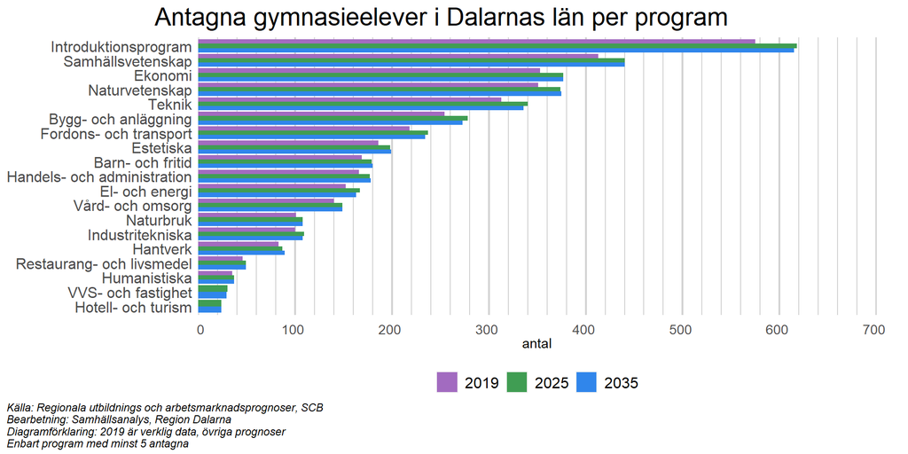

Figur 28

## 4.2 Högskolan

De som tog examen från Högskolan Dalarna läsåret 2020 gjorde det i stor utsträckning från två program, hälso- och sjukvård samt pedagogik- och lärarutbildning. Andra populär program är företagsekonomin, handel och administration samt informations- och kommunikationsteknik (IKT).

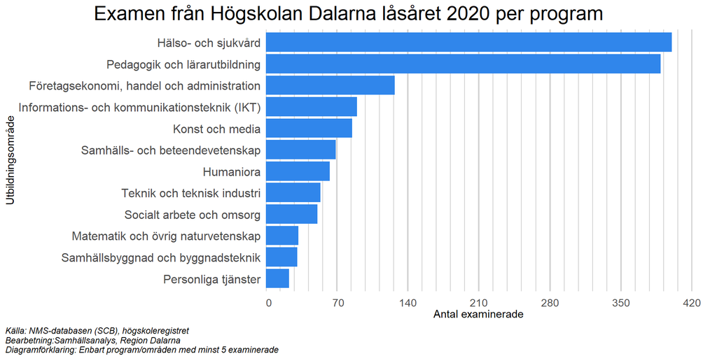

Figur 29

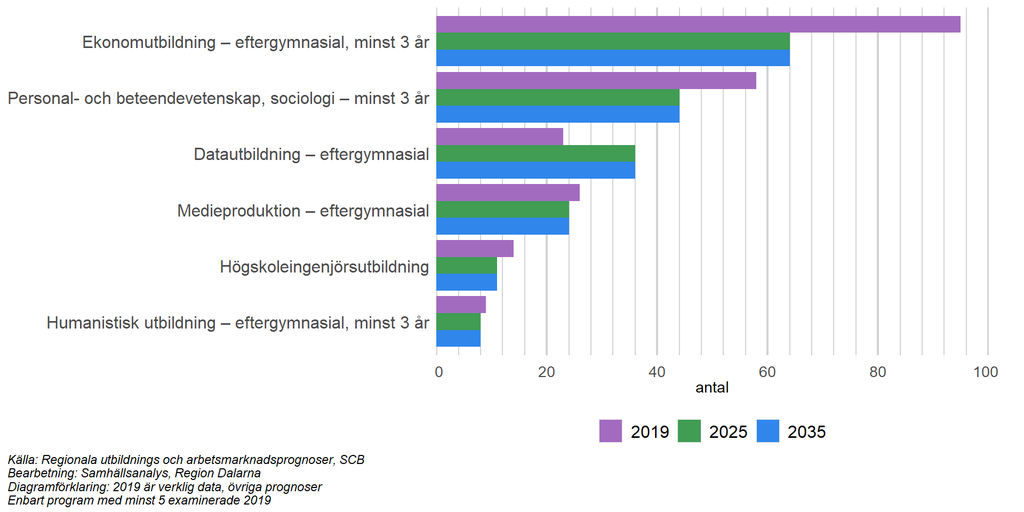

Figur 30

## 4.3 Yrkeshögskolan

**Mer information om statistiken**

En yrkeshögskola är en utbildningsform för yrkesinriktade studier på eftergymnasial nivå. Dess exakta roll varierar mellan olika länder. Inom yrkeshögskolan i Sverige finns två typer av examen på eftergymnasial nivå:

- yrkeshögskoleexamen, vilken motsvarar minst ett års studier på eftergymnasial nivå.
- kvalificerad yrkeshögskoleexamen, som motsvarar studier under minst två år på denna nivå.

Yrkeshögskolan i Dalarna är i första hand inriktad på utbildningar inom vård och omsorg, vilket återspeglar sig på länets arbetsmarknad. Den vanligaste branschen för examinerade från yrkeshögskolan är specialiserad sluten somatisk hälso- och sjukvård på sjukhus, med 156 förvärvsarbetande i Dalarna (den första figuren nedan). Det finns dock även utbildningar inom tillverkning och utvinning, då specifikt utvinning av annan malm.

Det vanligaste inriktningen för personer som tagit en examen för yrkeshögskolan och förvärvsarbetar i Dalarna är läkarsekreterarutbildning, med 129 förvärvsarbetande. Även relativt många med inriktningar mot psykiatrisk vård och tandsköterska förvärvsarbetar i Dalarna (den andra figuren nedan).

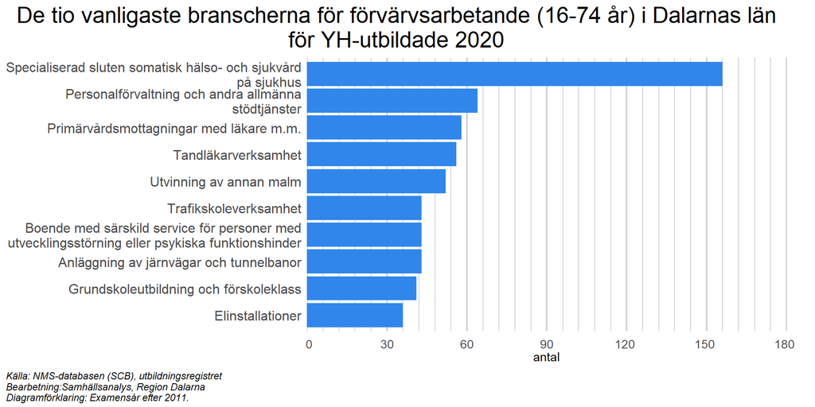

Figur 31

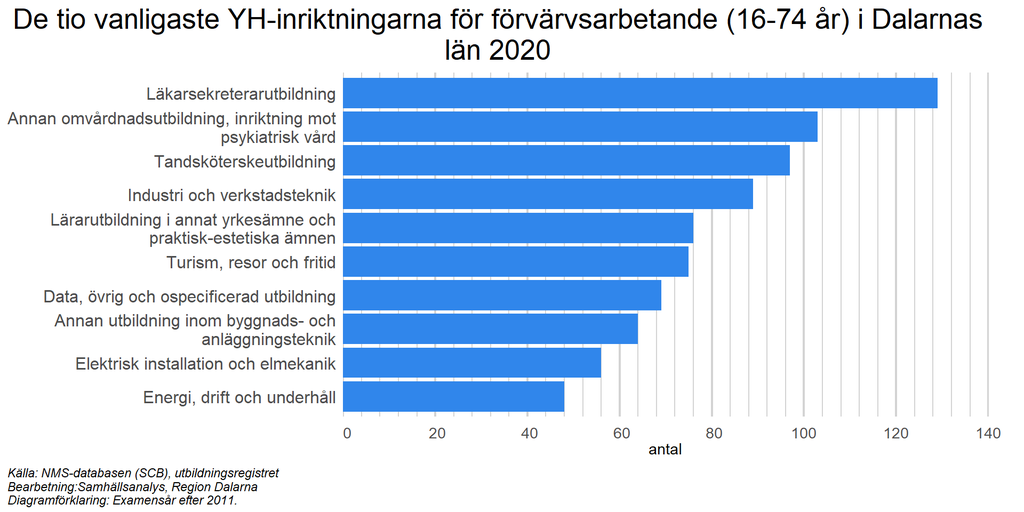

Figur 32

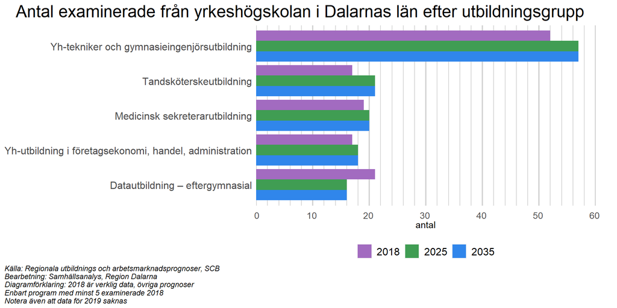

Figur 32